# RNA-seq differential gene expression

Uganda: HIV+ TB-induced RSTR vs LTBI

Basilin Benson basilinb@uw.edu & Kim Dill-McFarland kadm@uw.edu

version August 09, 2023

# Background

The purpose of this workflow is to identify TB-induced differentially expressed genes (DEG) in HIV+ individuals and compare these DEGs to those identified separately for HIV- individuals.

# Setup

Load packages

Set seed

# Data exploration

## Sample number

| Sample_Group | condition | n |
| --- | --- | --- |
| LTBI | MEDIA | 10 |
| LTBI | TB | 10 |
| RSTR | MEDIA | 9 |
| RSTR | TB | 9 |

## Co-variates

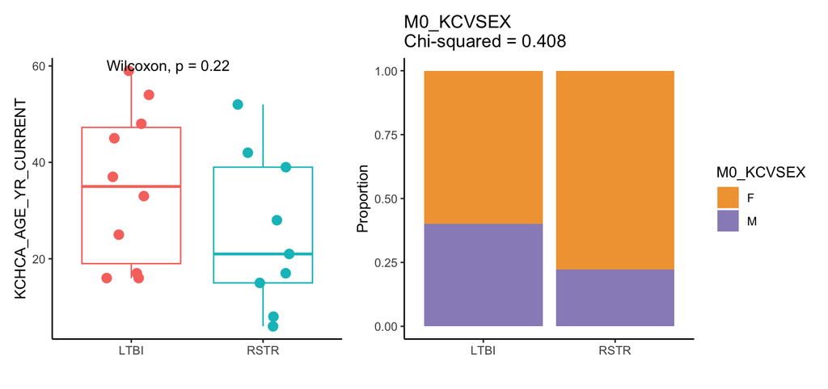

## PCA

Several variables of interest are shown here. Colors are consistent in PCA and dendrograms. To explore all variables, see https://kdillmcfarland.shinyapps.io/LamM_UC_RNAseq_PCA3/

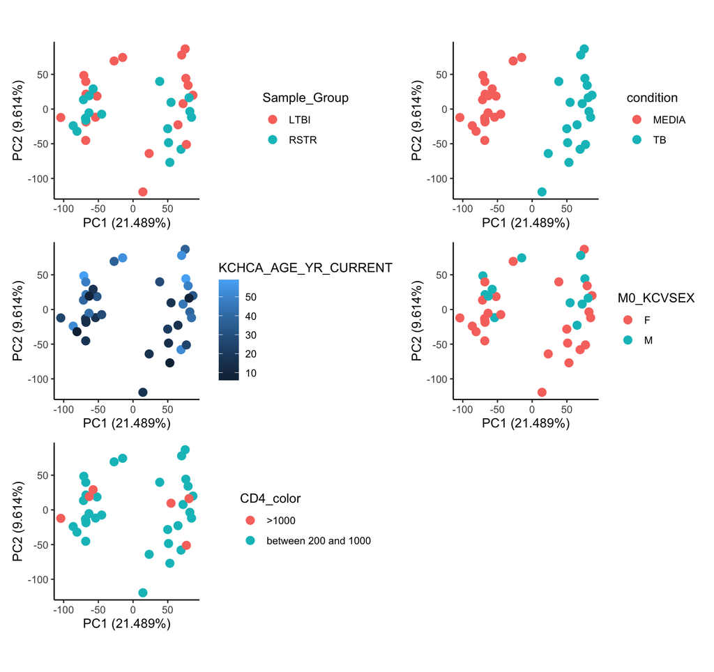

# Linear modeling

## Run models

Base model `~ condition*Sample_Group + (1|FULLIDNO)`

Add age and Sex as covariates `~ condition*Sample_Group + age + sex + (1|FULLIDNO)`

Add CD4 count as covariate `~ condition*Sample_Group + CD4 + (1|FULLIDNO)`

Add TB risk as covariate `~ condition*Sample_Group + RISK_SCORE + (1|FULLIDNO)`

## Assess co-variates

Age and sex do not improve fit for the majority of genes. These covariates are significant for few genes and also result in fewer RSTR significant genes, likely as a result of reduced power in the more complex model with this small data set.

```
##     Best fit Metric Total genes Mean delta Stdev delta
## 1   +Age+Sex    AIC          96    6.46137   13.828405
## 2 Base model    AIC       14753   11.05933    3.839104
## 3   +Age+Sex    BIC          29   15.43541   20.599339
## 4 Base model    BIC       14820   14.27927    3.917582
```

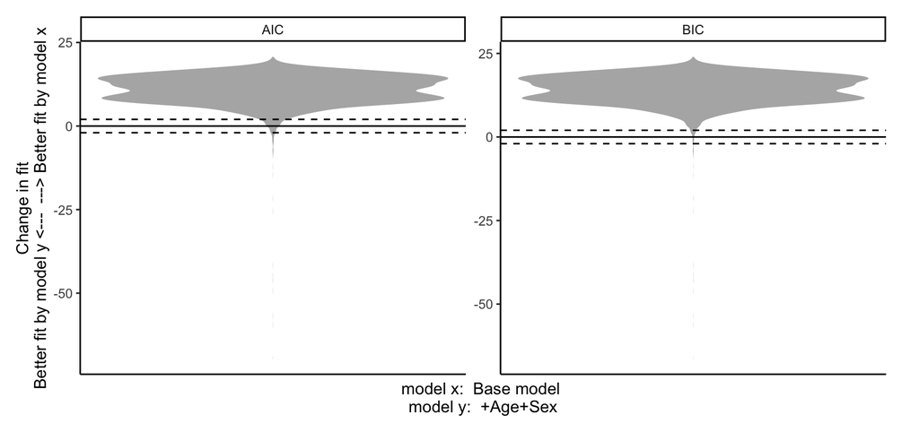

| variable | fdr_0.05 | fdr_0.1 | fdr_0.2 | fdr_0.3 | fdr_0.4 | fdr_0.5 |
| --- | --- | --- | --- | --- | --- | --- |
| (1 \| FULLIDNO) | 2018 | 2752 | 3860 | 4721 | 5527 | 6296 |
| condition | 9604 | 10314 | 11165 | 11788 | 12306 | 12759 |
| condition:Sample_Group | 1 | 1 | 11 | 15 | 41 | 103 |
| Sample_Group | NA | 7 | 15 | 31 | 68 | 158 |
| total (nonredundant) | 10045 | 10883 | 11857 | 12528 | 13074 | 13496 |

| variable | fdr_0.05 | fdr_0.1 | fdr_0.2 | fdr_0.3 | fdr_0.4 | fdr_0.5 |
| --- | --- | --- | --- | --- | --- | --- |
| (1 \| FULLIDNO) | 1850 | 2562 | 3556 | 4470 | 5243 | 6045 |
| condition | 9622 | 10330 | 11157 | 11812 | 12318 | 12760 |
| condition:Sample_Group | 1 | 1 | 7 | 20 | 38 | 107 |
| KCHCA_AGE_YR_CURRENT | 12 | 71 | 204 | 456 | 1155 | 2152 |
| M0_KCVSEX | 31 | 33 | 49 | 64 | 116 | 137 |
| Sample_Group | NA | NA | NA | NA | 5 | 5 |
| total (nonredundant) | 10041 | 10883 | 11837 | 12580 | 13139 | 13601 |

CD4 counts do not improve model fit for any gene, and this covariate is significant for very few genes.

```
##     Best fit Metric Total genes Mean delta Stdev delta
## 1 Base model    AIC       14849   15.99116    2.122942
## 2 Base model    BIC       14849   17.62875    2.122942
```

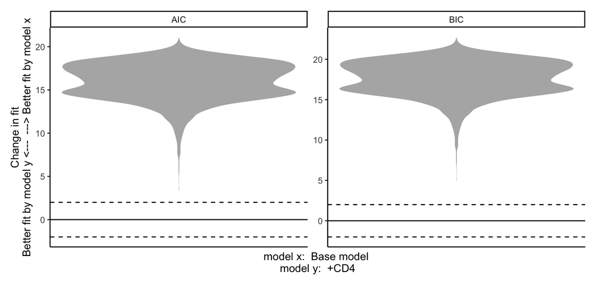

| variable | fdr_0.05 | fdr_0.1 | fdr_0.2 | fdr_0.3 | fdr_0.4 | fdr_0.5 |
| --- | --- | --- | --- | --- | --- | --- |
| (1 \| FULLIDNO) | 1949 | 2684 | 3801 | 4639 | 5459 | 6256 |
| CD4 | NA | 2 | 14 | 28 | 41 | 58 |
| condition | 9611 | 10314 | 11162 | 11794 | 12314 | 12766 |
| condition:Sample_Group | 1 | 1 | 11 | 16 | 62 | 112 |
| Sample_Group | 8 | 14 | 39 | 66 | 138 | 276 |
| total (nonredundant) | 10049 | 10879 | 11863 | 12529 | 13092 | 13511 |

TB risk score does not improve model fit for the majority of genes, and this covariate is significant for very few genes.

```
##     Best fit Metric Total genes Mean delta Stdev delta
## 1      +Risk    AIC         572   1.533478    1.483153
## 2 Base model    AIC       14277   4.260379    1.820993
## 3      +Risk    BIC         194   1.515550    1.446406
## 4 Base model    BIC       14655   5.769963    1.963407
```

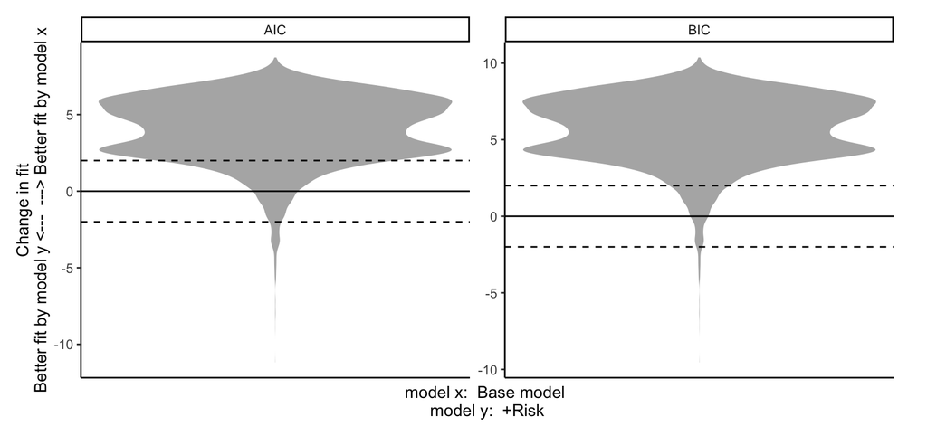

| variable | fdr_0.05 | fdr_0.1 | fdr_0.2 | fdr_0.3 | fdr_0.4 | fdr_0.5 |
| --- | --- | --- | --- | --- | --- | --- |
| (1 \| FULLIDNO) | 1960 | 2647 | 3670 | 4475 | 5213 | 6031 |
| condition | 9618 | 10303 | 11158 | 11768 | 12304 | 12761 |
| condition:Sample_Group | 1 | 1 | 11 | 18 | 47 | 107 |
| RISK_SCORE | NA | 4 | 5 | 11 | 23 | 169 |
| Sample_Group | 2 | 9 | 39 | 194 | 557 | 1157 |
| total (nonredundant) | 10045 | 10851 | 11831 | 12499 | 13085 | 13558 |

Given the above results and small sample size, no co-variates will be included in the final model.

## Significant genes

The final model is `~ condition*Sample_Group + (1|FULLIDNO)`

No interaction significant genes are also significant for the main RSTR term (Sample_Group). Thus, both gene lists may be assessed separately.

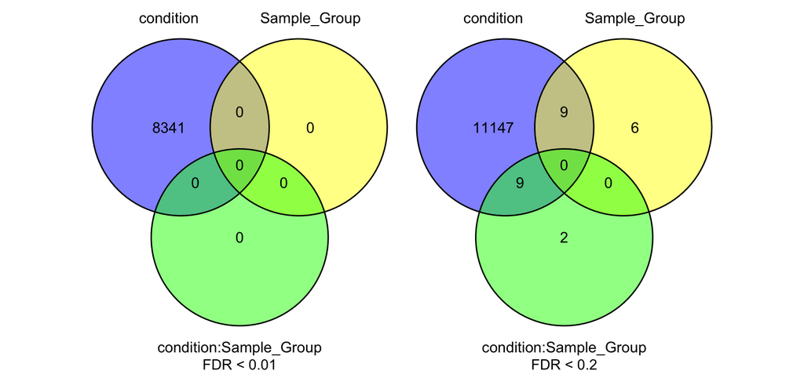

Significant RSTR genes include:

| symbol | variable | FDR |
| --- | --- | --- |
| DNASE2 | Sample_Group | 0.0600677 |
| SPIN1 | Sample_Group | 0.0600677 |
| YIPF4 | Sample_Group | 0.0600677 |
| TRAK1 | Sample_Group | 0.0600677 |
| DHFR2 | Sample_Group | 0.0745356 |
| C1D | Sample_Group | 0.0745356 |
| QRICH1 | Sample_Group | 0.0745356 |
| PHYKPL | Sample_Group | 0.1386297 |
| ITGB8 | Sample_Group | 0.1465534 |
| KPNA3 | Sample_Group | 0.1523019 |
| RAB2A | Sample_Group | 0.1788519 |
| SWAP70 | Sample_Group | 0.1788519 |
| RRM2B | Sample_Group | 0.1813448 |
| TTF1 | Sample_Group | 0.1813448 |
| BCO2 | Sample_Group | 0.1922158 |
| CDC42BPG | condition:Sample_Group | 0.0210268 |
| AQP6 | condition:Sample_Group | 0.1713300 |
| MACROH2A2 | condition:Sample_Group | 0.1713300 |
| CATSPERG | condition:Sample_Group | 0.1713300 |
| CDH13 | condition:Sample_Group | 0.1713300 |
| CCDC12 | condition:Sample_Group | 0.1713300 |
| SLC49A3 | condition:Sample_Group | 0.1713300 |
| TMEM11 | condition:Sample_Group | 0.1713300 |
| HLA-DQB1 | condition:Sample_Group | 0.1713300 |
| DMWD | condition:Sample_Group | 0.1713300 |
| ST6GALNAC3 | condition:Sample_Group | 0.1794286 |

## Pairwise contrasts

Because an interaction model was used, re-assess pairwise contrasts for just interaction term significant genes.

Also filter both contrast results to just the pairs of interest.

## Save final model

Add HGNC symbol to results.

# DEG enrichment

#### Hallmark gene sets (H)

```
## [1] "RSTR_DEG"
## [1] "Interaction_DEG"
## [1] "All_DEG"
```

#### Curated gene sets (C2)

```
## [1] "RSTR_DEG"
## [1] "Interaction_DEG"
## [1] "All_DEG"
```

#### Gene ontology (C5)

```
## [1] "RSTR_DEG"
## [1] "Interaction_DEG"
## [1] "All_DEG"
```

#### Immunologic (C7)

```
## [1] "RSTR_DEG"
## [1] "Interaction_DEG"
## [1] "All_DEG"
```

#### UniProt keyword

Calculated in STRING. No terms significant.

#### Summarise enrichment results

| group | size_group | gs_cat | FDR < 0.02 | FDR < 0.1 | FDR < 0.2 | FDR < 0.3 |
| --- | --- | --- | --- | --- | --- | --- |
| All_DEG | 26 | C2 | 0 | 0 | 5 | 5 |
|  |  | C5 | 0 | 0 | 24 | 29 |
|  |  | C7 | 0 | 1 | 1 | 157 |
|  |  | H | 0 | 0 | 0 | 0 |
| Interaction_DEG | 11 | C2 | 0 | 1 | 1 | 1 |
|  |  | C5 | 0 | 0 | 0 | 0 |
|  |  | C7 | 0 | 0 | 11 | 11 |
|  |  | H | 0 | 0 | 0 | 0 |
| RSTR_DEG | 15 | C2 | 0 | 0 | 2 | 2 |
|  |  | C5 | 0 | 0 | 8 | 8 |
|  |  | C7 | 0 | 88 | 92 | 92 |
|  |  | H | 0 | 0 | 0 | 0 |

Viewing just C2 for brevity. FDR < 0.3 and overlap > 1

All RSTR and interaction DEG

| group | size_group | gs_cat | pathway | group_in_pathway | k/K | FDR |
| --- | --- | --- | --- | --- | --- | --- |
| All_DEG | 26 | C2 | REACTOME_METABOLISM_OF_VITAMINS_AND_COFACTORS | 2 | 0.0098522 | 0.1999946 |
|  |  |  | KEGG_CELL_ADHESION_MOLECULES_CAMS | 2 | 0.0078431 | 0.1999946 |
|  |  |  | KEGG_SYSTEMIC_LUPUS_ERYTHEMATOSUS | 2 | 0.0075758 | 0.1999946 |
|  |  |  | REACTOME_INTERFERON_SIGNALING | 2 | 0.0065359 | 0.1999946 |
|  |  |  | REACTOME_EXTRACELLULAR_MATRIX_ORGANIZATION | 2 | 0.0062893 | 0.1999946 |

RSTR DEG

| group | size_group | gs_cat | pathway | group_in_pathway | k/K | FDR |
| --- | --- | --- | --- | --- | --- | --- |
| RSTR_DEG | 15 | C2 | REACTOME_METABOLISM_OF_VITAMINS_AND_COFACTORS | 2 | 0.0098522 | 0.1230956 |
|  |  |  | REACTOME_EXTRACELLULAR_MATRIX_ORGANIZATION | 2 | 0.0062893 | 0.1230956 |

Iteraction DEG

| group | gs_cat | size_group | pathway | group_in_pathway | k/K | FDR |
| --- | --- | --- | --- | --- | --- | --- |
| Interaction_DEG | C2 | 11 | KEGG_SYSTEMIC_LUPUS_ERYTHEMATOSUS | 2 | 0.0075758 | 0.0754893 |

# Gene set enrichment analysis (GSEA)

Extract fold change estimates

#### Hallmark gene sets (H)

Table shows RSTR significant (FDR < 0.1) normalized enrichment scores in 4 contrasts of interest. If `NA` in summary table, term was not significant in that contrast (FDR > 0.1).

| pathway | MEDIA RSTR-MEDIA LTBI | TB LTBI-MEDIA LTBI | TB RSTR-MEDIA RSTR | TB RSTR-TB LTBI |
| --- | --- | --- | --- | --- |
| HALLMARK_ALLOGRAFT_REJECTION | -1.945088 | 2.333767 | 2.204579 | -1.851390 |
| HALLMARK_APICAL_JUNCTION | -1.397183 | NA | 1.325840 | NA |
| HALLMARK_COAGULATION | 1.410910 | 1.467306 | 1.450976 | NA |
| HALLMARK_EPITHELIAL_MESENCHYMAL_TRANSITION | 1.382955 | 2.253765 | 2.170007 | NA |
| HALLMARK_INTERFERON_ALPHA_RESPONSE | -1.962830 | 2.536565 | 2.563013 | -1.770713 |
| HALLMARK_INTERFERON_GAMMA_RESPONSE | -2.101710 | 2.681759 | 2.615834 | -1.962970 |
| HALLMARK_NOTCH_SIGNALING | 1.570594 | NA | NA | NA |
| HALLMARK_TGF_BETA_SIGNALING | 1.801154 | NA | NA | NA |
| HALLMARK_TNFA_SIGNALING_VIA_NFKB | 1.511451 | 3.245914 | 3.111015 | NA |
| HALLMARK_MYOGENESIS | NA | 1.346605 | 1.642486 | 1.657118 |

# DEG association with covariates

Because the simplest model was chosen, we further assess DEGs for differences in covariates not included in the final model.

Most importantly, TB risk score since it differs between RSTR and LTBI.

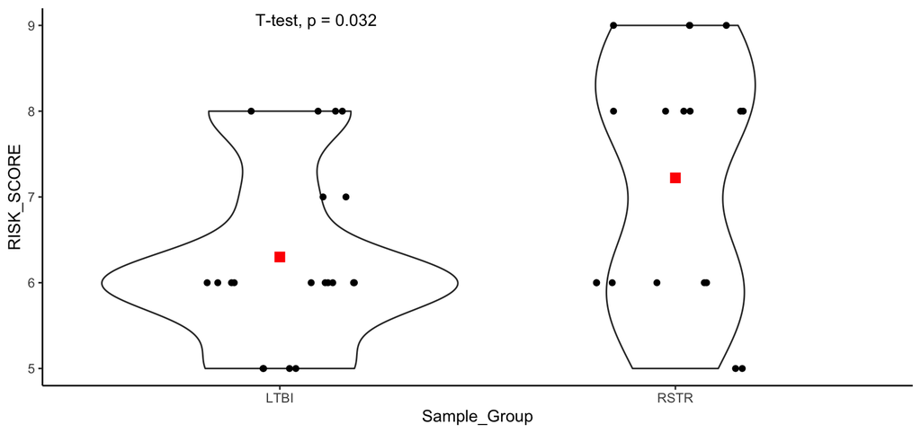

Risk score is associated with 2 RSTR DEGs in the media but not TB condition.

```
## # A tibble: 2 × 5
##   condition gene            variable   estimate    FDR
##   <chr>     <chr>           <chr>         <dbl>  <dbl>
## 1 MEDIA     ENSG00000140945 RISK_SCORE  -0.826  0.0920
## 2 MEDIA     ENSG00000198218 RISK_SCORE   0.0499 0.0920
```